# Review Session

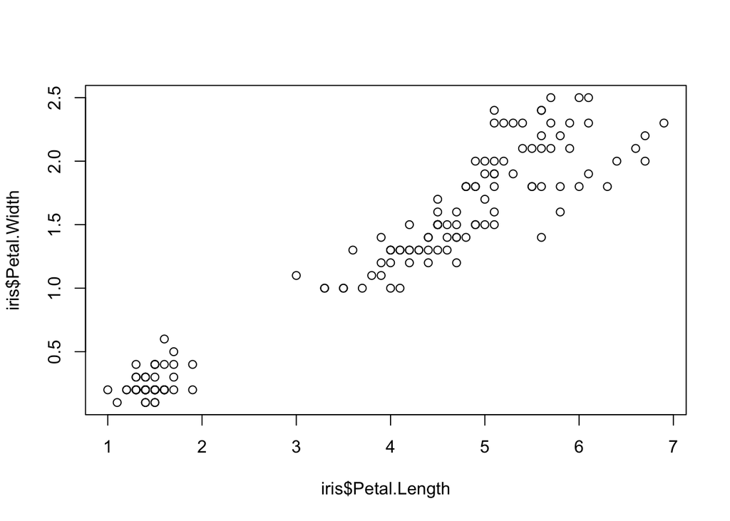

```r
plot(iris$Petal.Length, iris$Petal.Width) # right away we see a clear positive relationship. And this makes sense that a longer petal would also be wider.
```

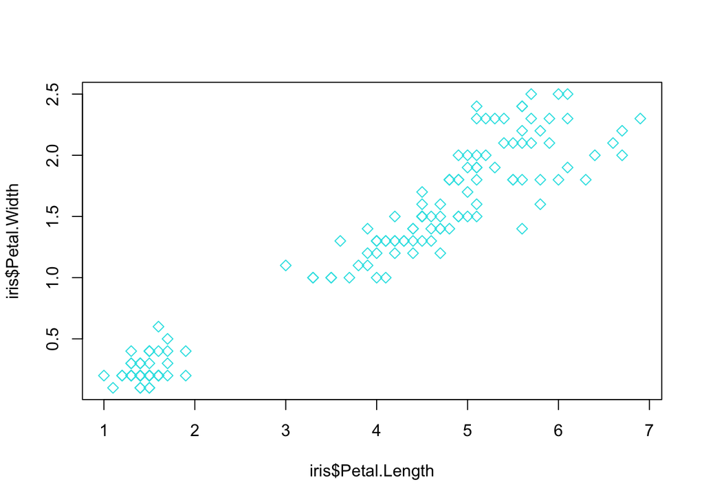

```r
# let's see what else we can do with the function plot
plot(iris$Petal.Length, iris$Petal.Width, pch = 5, col = 5) # pch tells R to use different symbols to point out the observations (eg pch = 1 is circle and pch = 2 is triangle). col is same but for color instead of shape.
```

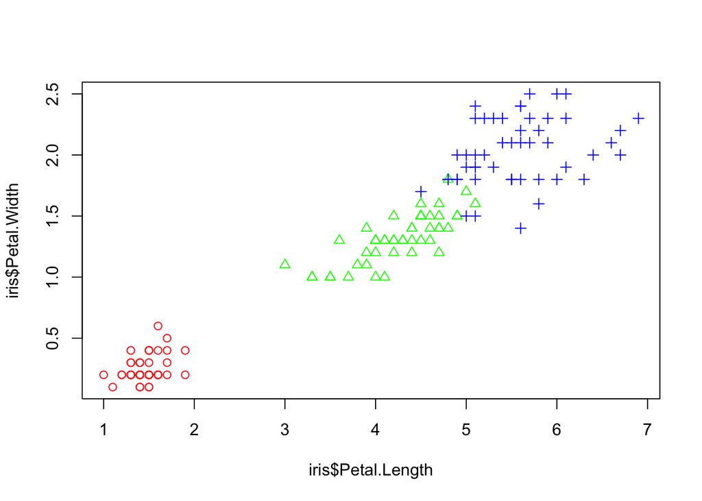

```r
# we can use these tools to symbolize the category an observation belongs to. In the iris dataset, species is a categorical variable
plot(iris$Petal.Length, iris$Petal.Width,
     pch = as.numeric(iris$Species),
     col = rainbow(3)[iris$Species])
```

## Iris with Tidyverse

We see that R on its own is already a pretty powerful tool. But we can do even more using packages that people before us prepared.

```r
# we can take a look at the summary statistics altogether using describe() from psych package
describe(iris[-5], fast = TRUE) # iris[-5] means ignore the fifth column. i want to ignore it in the summary stats for now bcuz it's a string
```

```
##              vars   n mean   sd min max range   se
## Sepal.Length    1 150 5.84 0.83 4.3 7.9   3.6 0.07
## Sepal.Width     2 150 3.06 0.44 2.0 4.4   2.4 0.04
## Petal.Length    3 150 3.76 1.77 1.0 6.9   5.9 0.14
## Petal.Width     4 150 1.20 0.76 0.1 2.5   2.4 0.06
```

```r
# we can use the dplyr package to produce a similar table by species
# dplyr is a super commonly used package to clean, transform, and summarize data
# an important thing to know in order to use it efficiently is the pipe operator   %>%
# pipe takes the output of one line and makes it the first input of the function in the next line
# it makes things more intuitive and easy to follow (otherwise you will have to deal with lots crowded lines or nested parentheses to perform operations in the order you want)
# it's also efficient in terms of code length and legibility because most functions that transform data take the dataset as its first argument

iris_summary <- iris %>% # piping iris into group_by
  group_by( Species) %>% # piping grouped iris into select
  select(Sepal.Length, Sepal.Width) %>% # selecting variables of interest
  summarise( sl_mean = mean(Sepal.Length), #
             sl_sd   = sd(Sepal.Length),
             sw_mean = mean(Sepal.Width),
             sw_sd   = sd(Sepal.Width)
             )
head(iris_summary)
```

```
## # A tibble: 3 x 5
##   Species    sl_mean sl_sd sw_mean sw_sd
##   <fct>        <dbl> <dbl>   <dbl> <dbl>
## 1 setosa        5.01 0.352    3.43 0.379
## 2 versicolor    5.94 0.516    2.77 0.314
## 3 virginica     6.59 0.636    2.97 0.322
```

```r
# the units are all in centimeters but let's still go ahead and normalize/standardize our variables as a practice. plus, it was mentioned in class as a good way to address the differences in magnitudes of units which will effect coefficient magnitudes and in turn how much or little they are shrinked

iris_standard <- iris %>% # pipe iris into rename
  rename(
        sl = Sepal.Length, # shorten names bcuz i will be referring to them many times
        sw = Sepal.Width,
        pl = Petal.Length,
        pw = Petal.Width) %>% # pipe the iris with shortened names into mutate
  mutate( # mutate is a super useful function that helps you create new variables
       norm_sl = ( sl-mean(sl) ) / sd(sl),
       norm_sw = ( sw-mean(sw) ) / sd(sw),
       norm_pl = ( pl-mean(pl) ) / sd(pl),
       norm_pw = ( pw-mean(pw) ) / sd(pw)
       )

# i often align the equals signs across lines to emphasize a pattern
# i use spaces to make it more visible which parentheses correspond to one another

head(iris_standard)
```

```
##    sl  sw  pl  pw Species    norm_sl     norm_sw   norm_pl   norm_pw
## 1 5.1 3.5 1.4 0.2  setosa -0.8976739  1.01560199 -1.335752 -1.311052
## 2 4.9 3.0 1.4 0.2  setosa -1.1392005 -0.13153881 -1.335752 -1.311052
## 3 4.7 3.2 1.3 0.2  setosa -1.3807271  0.32731751 -1.392399 -1.311052
## 4 4.6 3.1 1.5 0.2  setosa -1.5014904  0.09788935 -1.279104 -1.311052
## 5 5.0 3.6 1.4 0.2  setosa -1.0184372  1.24503015 -1.335752 -1.311052
## 6 5.4 3.9 1.7 0.4  setosa -0.5353840  1.93331463 -1.165809 -1.048667
```

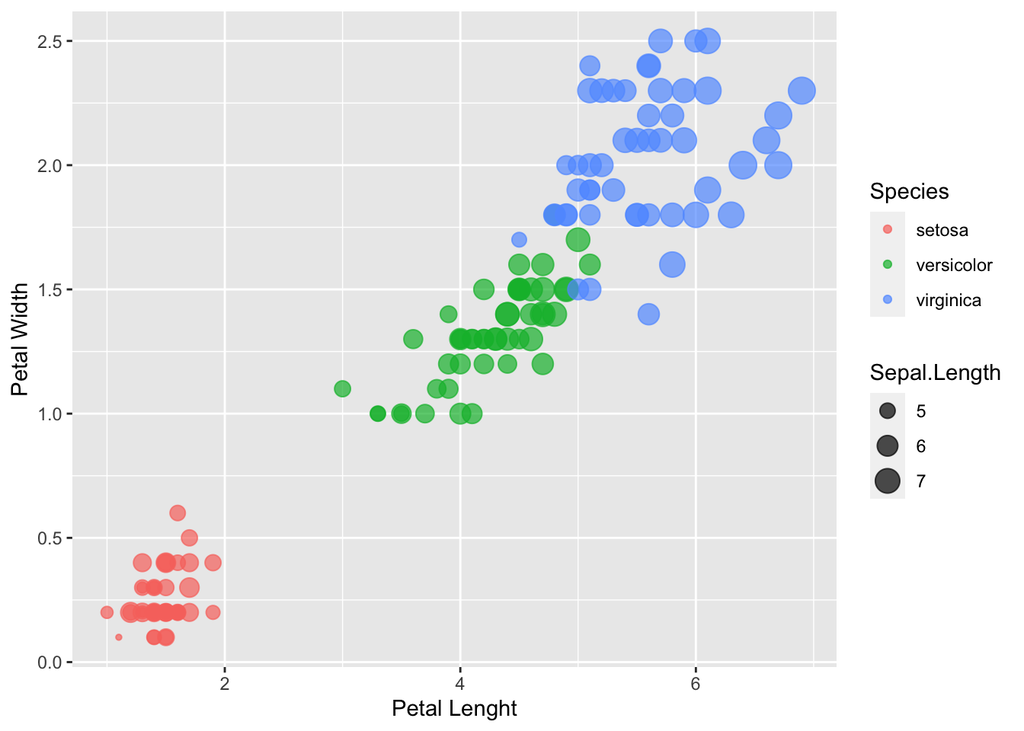

```r
# in ggplot, we use + to add more characteristics to a plot.
# you can save the plot as  an object and keep adding more stuff to it with +

scatter_petal <- iris %>%
  ggplot( aes( x=Petal.Length,y=Petal.Width,
              color=Species, size=Sepal.Length)) +
  # now we can color by a category and size by a numerical variable
  # aes stands for aesthetics. first we enter variables we want on the x-axis and y-axis
  geom_point(alpha=0.7) +
  # geom_point makes it a scatter plot (good to compare continuous variables)
  # alpha (0,1) is a parameter for opacity: closer to 0 => more transparent.
  xlab("Petal Lenght") + ylab("Petal Width")+
  # label each axis with its variable
  guides(fill = guide_legend(title = "Species"))

# now let's print the plot

scatter_petal
```

```r
# let's do one with normalized values
names(iris_standard)
```

```
## [1] "sl"      "sw"      "pl"      "pw"      "Species" "norm_sl" "norm_sw"
## [8] "norm_pl" "norm_pw"
```

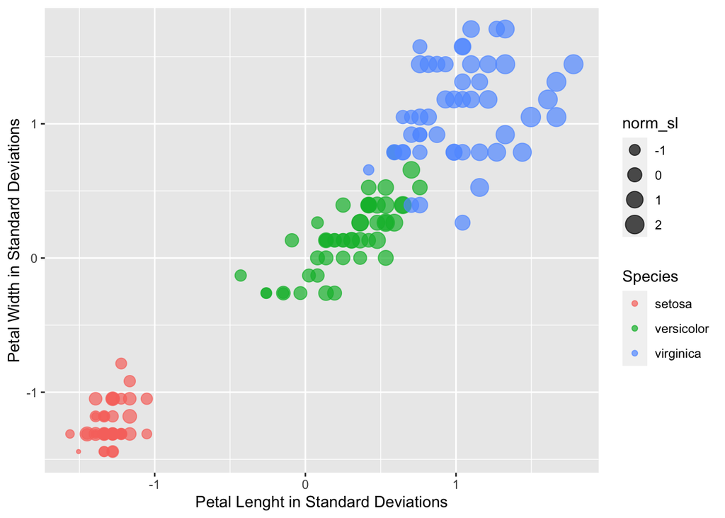

```r
normal_petal <- iris_standard %>%
  ggplot( aes( x=norm_pl,y=norm_pw,
              color=Species, size=norm_sl)) +
  geom_point(alpha=0.7) +
  xlab("Petal Lenght in Standard Deviations") + ylab("Petal Width in Standard Deviations")+
  guides(fill = guide_legend(title = "Species"))

normal_petal
```

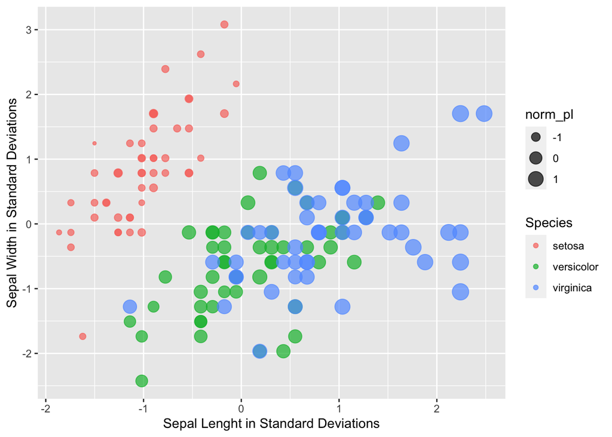

```r
#

normal_sepal <- iris_standard %>%
  ggplot( aes( x=norm_sl,y=norm_sw,
              color=Species, size=norm_pl)) +
  geom_point(alpha=0.7) +
  xlab("Sepal Lenght in Standard Deviations") + ylab("Sepal Width in Standard Deviations")+
  guides(fill = guide_legend(title = "Species"))

normal_sepal
```

We see that for setosa flowers Sepal Length and Width increase together, wheras for virginica flowers Sepal Width does not change much while Sepal Length varies a lot.

This is only a glimpse of what dplyr and ggplot2 can do (both are part of tidyverse). To see more examples, check out kaggle. It has many datasets, tutorials, and community uploaded code. I would highly recommend looking at what people have done with the [Heart Disease UCI dataset](https://www.kaggle.com/ronitf/heart-disease-uci) for example. First read the description and explore the variables yourself (their summary stats and histograms are on the main page). Then, go to code and filter by R. You will find good examples. Try to understand and apply them yourself. It is the only way to get better, and you can do it.

## Probability Models

Now let’s build some probability models and compare their out of sample fit.

```r
# Let's focus on base R for model building for now and we can learn and use ML libraries later in the course
# I want binary variables for each category. It will be easier for me to build and test a simple model with base R functions using binary instead of categorical

iris_standard  <- iris_standard %>%
  mutate(
    is_setosa = 1*(Species == "setosa"    ),
    # using logical == to check if Species takes that value.
    # mutate will loop the vector checking each row.
    # i multiply by 1 bcuz want the variable to be 1 or 0 instead of TRUE FALSE
    is_versic = 1*(Species == "versicolor"),
    is_virgin = 1*(Species == "virginica" ),
    # i want to include some squared terms
    sl2 = sl^2,
    sw2 = sw^2,
    pl2 = pl^2,
    pw2 = pw^2
    # be careful about squaring a normalized variable!
    # think about why that might be poroblem
  )

# whenever you do something that is supposed to be random, you should set a seed. The computer will use this seed to randomize.
# This is for reproducibility purposes (so that others can go and get the same results)
set.seed(121)

# pick your favorite number.  I like 11 so I will pick 121
# normally, you want to set it to regular number like 100 or 1 so that you don't draw attention. but believe me playing with silly things like this can make boring tasks more engaging and fun

# Now split the data into train and test

iris_standard$rando  <- runif(150) # this is the R base way of creating a new variable. it's fast and easy if you are making or changing a single variable. otherwise, go with dplyr and pipe into mutate.

# here we are drawing a random number for each observation and I will use them to split the data.
# the draws are from uniform distribution between 0 and 1. so one would expect one fourth of them to be below 0.25

iris_train <- filter(iris_standard, rando > 0.25)
iris_test <- filter(iris_standard, rando < 0.25)

# let's compare the count of observations of each category
# this is to see if we have balanced and comparable training and testing datasets
# since we cut it three quarters in train and one quarter in test
# ideally, we want around 37 obs per category for train and 12 for test
summary(iris_train$Species)
```

```
##     setosa versicolor  virginica
##         37         36         38
```

```r
summary(iris_test$Species)
```

```
##     setosa versicolor  virginica
##         13         14         12
```

```r
# it seems close let's run the models

# a linear probability model
setosa_lpm <- lm(is_setosa ~ norm_sl + norm_sw + norm_pl + norm_pw,
            data = iris_train)

summary(setosa_lpm)
```

```
##
## Call:
## lm(formula = is_setosa ~ norm_sl + norm_sw + norm_pl + norm_pw,
##     data = iris_train)
##
## Residuals:
##      Min       1Q   Median       3Q      Max
## -0.32067 -0.09897  0.01546  0.10501  0.41796
##
## Coefficients:
##             Estimate Std. Error t value Pr(>|t|)
## (Intercept)  0.33530    0.01395  24.032  < 2e-16 ***
## norm_sl      0.05995    0.03762   1.594    0.114
## norm_sw      0.10640    0.02073   5.133 1.30e-06 ***
## norm_pl     -0.39146    0.07830  -4.999 2.29e-06 ***
## norm_pw     -0.05491    0.05469  -1.004    0.318
## ---
## Signif. codes:  0 '***' 0.001 '**' 0.01 '*' 0.05 '.' 0.1 ' ' 1
##
## Residual standard error: 0.1468 on 106 degrees of freedom
## Multiple R-squared:  0.9075, Adjusted R-squared:  0.904
## F-statistic: 259.8 on 4 and 106 DF,  p-value: < 2.2e-16
```

```r
# the model suggests that sepal width and petal length are the most important factors (sepal length and petal width are probably highly collinear to these two and thus not adding much info)
# let's store the predictions into iris_test
iris_test$setosahat_lpm <-  predict(setosa_lpm, newdata = iris_test)

# Out of sample mean squared error
mean( (iris_test$is_setosa - iris_test$setosahat_lpm)^2 ) # 0.02019706
```

```
## [1] 0.02019706
```

```r
# even tho our model is very simple and sample size is small, this is not a bad out of sample MSE.
# let's include squared terms to see if we can improve

names(iris_train)
```

```
##  [1] "sl"        "sw"        "pl"        "pw"        "Species"   "norm_sl"
##  [7] "norm_sw"   "norm_pl"   "norm_pw"   "is_setosa" "is_versic" "is_virgin"
## [13] "sl2"       "sw2"       "pl2"       "pw2"       "rando"
```

```r
setosa_lpm2 <- lm(is_setosa ~ sl + sw + pl + pw + sl2 + sw2 + pl2 + pw2,
            data = iris_train)
iris_test$setosahat_lpm2 <-  predict(setosa_lpm2, newdata = iris_test)
mean( (iris_test$is_setosa - iris_test$setosahat_lpm2)^2 ) # 0.005017416 much better
```

```
## [1] 0.005017416
```

```r
# I tried logistic and probit regressions but they did not converge well possibly because of lack of observation or my misuse.
# you can play with the commented code below and solve the issue probably:

# setosa_logit <- glm(is_setosa ~ norm_sl + norm_sw + norm_pl + norm_pw,
#            data = iris_train, family = "binomial")
# setosa_logit <- glm(is_setosa ~ sl + sw + pl + pw + sl2 + sw2 + pl2 + pw2,
#            data = iris_train, family = "binomial")
# setosa_pro <- glm(is_setosa ~ norm_sl + norm_sw + norm_pl + norm_pw,
#            data = iris_train, family = binomial(link = "probit"))
```

there are libraries that do this train-test splitting and model comparison automatically for you. They can also repeat the process many times at once: K-Fold Cross-Validation. One of them is **caret**, which combines useful functions from several other packages without fully loading them.

I hope this was helpful yall. Shoot me R or assignment questions whenever. See you next review session (hopefully live on zoom instead of over text here :))

Peace,

Lutfi